# Predict Bike Sharing Demand with AutoGluon Template

## Project: Predict Bike Sharing Demand with AutoGluon

This notebook is a template with each step that you need to complete for the project.

Please fill in your code where there are explicit `?` markers in the notebook. You are welcome to add more cells and code as you see fit.

Once you have completed all the code implementations, please export your notebook as a HTML file so the reviews can view your code. Make sure you have all outputs correctly outputted.

`File-> Export Notebook As... -> Export Notebook as HTML`

There is a writeup to complete as well after all code implememtation is done. Please answer all questions and attach the necessary tables and charts. You can complete the writeup in either markdown or PDF.

Completing the code template and writeup template will cover all of the rubric points for this project.

The rubric contains "Stand Out Suggestions" for enhancing the project beyond the minimum requirements. The stand out suggestions are optional. If you decide to pursue the "stand out suggestions", you can include the code in this notebook and also discuss the results in the writeup file.

## Step 1: Create an account with Kaggle

### Create Kaggle Account and download API key

Below is example of steps to get the API username and key. Each student will have their own username and key.

1. Open account settings.

2. Scroll down to API and click Create New API Token.

3. Open up `kaggle.json` and use the username and key.


## Step 2: Download the Kaggle dataset using the kaggle python library

### Open up Sagemaker Studio and use starter template

1. Notebook should be using a `ml.t3.medium` instance (2 vCPU + 4 GiB)
2. Notebook should be using kernal: `Python 3 (MXNet 1.8 Python 3.7 CPU Optimized)`

### Install packages

```python
!pip install -U pip
!pip install -U setuptools wheel
!pip install -U "mxnet<2.0.0" bokeh==2.0.1
!pip install autogluon --no-cache-dir
# Without --no-cache-dir, smaller aws instances may have trouble installing
```

[output not shown]

[output cut: 65 more lines]

[output not shown]

```python
!pip install -U pip
!pip install -U setuptools wheel
!pip install kaggle
!pip install -U "mxnet<2.0.0" bokeh==2.0.1
!pip install autogluon --no-cache-dir
# Without --no-cache-dir, smaller aws instances may have trouble installing
```

[output not shown]

[output cut: 68 more lines]

[output not shown]

### Setup Kaggle API Key

```python
# create the .kaggle directory and an empty kaggle.json file
!mkdir -p /kaggle/.kaggle
!touch /kaggle/.kaggle/kaggle.json
!chmod 600 /kaggle/.kaggle/kaggle.json
```

```
mkdir: cannot create directory ‘/kaggle’: Permission denied
touch: cannot touch '/kaggle/.kaggle/kaggle.json': No such file or directory
chmod: cannot access '/kaggle/.kaggle/kaggle.json': No such file or directory
```

```python
# Fill in your user name and key from creating the kaggle account and API token file
import json
kaggle_username = "bumpybanana"
kaggle_key = "308ee16d2a2b8a2baa3b103d63002ce6"

# Save API token the kaggle.json file
with open("/root/.kaggle/kaggle.json", "w") as f:
    f.write(json.dumps({"username": kaggle_username, "key": kaggle_key}))
```

### Download and explore dataset

### Go to the [bike sharing demand competition](https://www.kaggle.com/c/bike-sharing-demand) and agree to the terms

```python
# Download the dataset, it will be in a .zip file so you'll need to unzip it as well.
!kaggle competitions download -c bike-sharing-demand
# If you already downloaded it you can use the -o command to overwrite the file
!unzip -o bike-sharing-demand.zip
```

```
Downloading bike-sharing-demand.zip to /home/sagemaker-user/nd009t-c1-intro-to-ml-project-starter
Archive:  bike-sharing-demand.zip
  inflating: sampleSubmission.csv
  inflating: test.csv
  inflating: train.csv
```

[output not shown]

```python
import pandas as pd
from autogluon.tabular import TabularPredictor
```

```python
# Create the train dataset in pandas by reading the csv
# Set the parsing of the datetime column so you can use some of the `dt` features in pandas later
train = pd.read_csv('train.csv', parse_dates=['datetime'])
print(train.dtypes)
train.head()
```

```
datetime      datetime64[ns]
season                 int64
holiday                int64
workingday             int64
weather                int64
temp                 float64
atemp                float64
humidity               int64
windspeed            float64
casual                 int64
registered             int64
count                  int64
dtype: object
```

|  | datetime | season | holiday | workingday | weather | temp | atemp | humidity | windspeed | casual | registered | count |
| --- | --- | --- | --- | --- | --- | --- | --- | --- | --- | --- | --- | --- |
| 0 | 2011-01-01 00:00:00 | 1 | 0 | 0 | 1 | 9.84 | 14.395 | 81 | 0.0 | 3 | 13 | 16 |
| 1 | 2011-01-01 01:00:00 | 1 | 0 | 0 | 1 | 9.02 | 13.635 | 80 | 0.0 | 8 | 32 | 40 |
| 2 | 2011-01-01 02:00:00 | 1 | 0 | 0 | 1 | 9.02 | 13.635 | 80 | 0.0 | 5 | 27 | 32 |
| 3 | 2011-01-01 03:00:00 | 1 | 0 | 0 | 1 | 9.84 | 14.395 | 75 | 0.0 | 3 | 10 | 13 |
| 4 | 2011-01-01 04:00:00 | 1 | 0 | 0 | 1 | 9.84 | 14.395 | 75 | 0.0 | 0 | 1 | 1 |

```python
# Simple output of the train dataset to view some of the min/max/varition of the dataset features.
train.describe()
```

|  | season | holiday | workingday | weather | temp | atemp | humidity | windspeed | casual | registered | count |
| --- | --- | --- | --- | --- | --- | --- | --- | --- | --- | --- | --- |
| count | 10886.000000 | 10886.000000 | 10886.000000 | 10886.000000 | 10886.00000 | 10886.000000 | 10886.000000 | 10886.000000 | 10886.000000 | 10886.000000 | 10886.000000 |
| mean | 2.506614 | 0.028569 | 0.680875 | 1.418427 | 20.23086 | 23.655084 | 61.886460 | 12.799395 | 36.021955 | 155.552177 | 191.574132 |
| std | 1.116174 | 0.166599 | 0.466159 | 0.633839 | 7.79159 | 8.474601 | 19.245033 | 8.164537 | 49.960477 | 151.039033 | 181.144454 |
| min | 1.000000 | 0.000000 | 0.000000 | 1.000000 | 0.82000 | 0.760000 | 0.000000 | 0.000000 | 0.000000 | 0.000000 | 1.000000 |
| 25% | 2.000000 | 0.000000 | 0.000000 | 1.000000 | 13.94000 | 16.665000 | 47.000000 | 7.001500 | 4.000000 | 36.000000 | 42.000000 |
| 50% | 3.000000 | 0.000000 | 1.000000 | 1.000000 | 20.50000 | 24.240000 | 62.000000 | 12.998000 | 17.000000 | 118.000000 | 145.000000 |
| 75% | 4.000000 | 0.000000 | 1.000000 | 2.000000 | 26.24000 | 31.060000 | 77.000000 | 16.997900 | 49.000000 | 222.000000 | 284.000000 |
| max | 4.000000 | 1.000000 | 1.000000 | 4.000000 | 41.00000 | 45.455000 | 100.000000 | 56.996900 | 367.000000 | 886.000000 | 977.000000 |

```python
# Create the test pandas dataframe in pandas by reading the csv, remember to parse the datetime!
test = pd.read_csv('test.csv', parse_dates=['datetime'])
test.head()
```

|  | datetime | season | holiday | workingday | weather | temp | atemp | humidity | windspeed |
| --- | --- | --- | --- | --- | --- | --- | --- | --- | --- |
| 0 | 2011-01-20 00:00:00 | 1 | 0 | 1 | 1 | 10.66 | 11.365 | 56 | 26.0027 |
| 1 | 2011-01-20 01:00:00 | 1 | 0 | 1 | 1 | 10.66 | 13.635 | 56 | 0.0000 |
| 2 | 2011-01-20 02:00:00 | 1 | 0 | 1 | 1 | 10.66 | 13.635 | 56 | 0.0000 |
| 3 | 2011-01-20 03:00:00 | 1 | 0 | 1 | 1 | 10.66 | 12.880 | 56 | 11.0014 |
| 4 | 2011-01-20 04:00:00 | 1 | 0 | 1 | 1 | 10.66 | 12.880 | 56 | 11.0014 |

```python
# Same thing as train and test dataset
submission = pd.read_csv('sampleSubmission.csv', parse_dates=['datetime'])
submission.head()
```

|  | datetime | count |
| --- | --- | --- |
| 0 | 2011-01-20 00:00:00 | 0 |
| 1 | 2011-01-20 01:00:00 | 0 |
| 2 | 2011-01-20 02:00:00 | 0 |
| 3 | 2011-01-20 03:00:00 | 0 |
| 4 | 2011-01-20 04:00:00 | 0 |

## Step 3: Train a model using AutoGluon’s Tabular Prediction

Requirements:

- We are predicting `count`, so it is the label we are setting.
- Ignore `casual` and `registered` columns as they are also not present in the test dataset.
- Use the `root_mean_squared_error` as the metric to use for evaluation.
- Set a time limit of 10 minutes (600 seconds).
- Use the preset `best_quality` to focus on creating the best model.

```python
train_set = train.drop(['casual', 'registered'], axis=1)

predictor = TabularPredictor(label='count',
                            eval_metric='root_mean_squared_error').fit(train_set,
                                                                      time_limit=600,
                                                                      presets='best_quality')
```

[output not shown]

[output cut: 34 more lines]

[output not shown]

[output not shown]

[output not shown]

[output not shown]

[output not shown]

[output not shown]

[output not shown]

[output not shown]

[output not shown]

[output not shown]

[output not shown]

[output not shown]

[output not shown]

[output cut: 93 more lines]

[output not shown]

### Review AutoGluon's training run with ranking of models that did the best.

```python
predictor.fit_summary()
```

```
*** Summary of fit() ***
Estimated performance of each model:
                     model   score_val              eval_metric  pred_time_val    fit_time  pred_time_val_marginal  fit_time_marginal  stack_level  can_infer  fit_order
0      WeightedEnsemble_L3  -53.103221  root_mean_squared_error      19.973970  406.293668                0.000602           0.029818            3       True         13
1   RandomForestMSE_BAG_L2  -53.421743  root_mean_squared_error      14.228565  334.024350                0.667612          39.395080            2       True         12
2          LightGBM_BAG_L2  -54.983549  root_mean_squared_error      13.858748  318.840031                0.297795          24.210762            2       True         11
3        LightGBMXT_BAG_L2  -60.556679  root_mean_squared_error      19.007961  342.658008                5.447008          48.028738            2       True         10
4    KNeighborsDist_BAG_L1  -84.125061  root_mean_squared_error       0.034918    0.031376                0.034918           0.031376            1       True          2
5      WeightedEnsemble_L2  -84.125061  root_mean_squared_error       0.035704    0.068274                0.000786           0.036899            2       True          9
6    KNeighborsUnif_BAG_L1 -101.546199  root_mean_squared_error       0.034648    0.034953                0.034648           0.034953            1       True          1
7   RandomForestMSE_BAG_L1 -116.548359  root_mean_squared_error       0.658814   14.330106                0.658814          14.330106            1       True          5
8     ExtraTreesMSE_BAG_L1 -124.600676  root_mean_squared_error       0.652031    7.000894                0.652031           7.000894            1       True          7
9          CatBoost_BAG_L1 -130.654759  root_mean_squared_error       0.122580  145.032047                0.122580         145.032047            1       True          6
10         LightGBM_BAG_L1 -131.054162  root_mean_squared_error       1.747604   27.507634                1.747604          27.507634            1       True          4
11       LightGBMXT_BAG_L1 -131.460909  root_mean_squared_error       9.911152   53.629189                9.911152          53.629189            1       True          3
12  NeuralNetFastAI_BAG_L1 -141.004273  root_mean_squared_error       0.399207   47.063070                0.399207          47.063070            1       True          8
Number of models trained: 13
Types of models trained:
{'StackerEnsembleModel_KNN', 'StackerEnsembleModel_NNFastAiTabular', 'StackerEnsembleModel_RF', 'StackerEnsembleModel_CatBoost', 'StackerEnsembleModel_XT', 'WeightedEnsembleModel', 'StackerEnsembleModel_LGB'}
Bagging used: True  (with 8 folds)
Multi-layer stack-ensembling used: True  (with 3 levels)
Feature Metadata (Processed):
(raw dtype, special dtypes):
('float', [])                : 3 | ['temp', 'atemp', 'windspeed']
('int', [])                  : 3 | ['season', 'weather', 'humidity']
('int', ['bool'])            : 2 | ['holiday', 'workingday']
('int', ['datetime_as_int']) : 5 | ['datetime', 'datetime.year', 'datetime.month', 'datetime.day', 'datetime.dayofweek']
*** End of fit() summary ***
```

[output not shown]

[output cut: 127 more lines]

[output not shown]

### Create predictions from test dataset

```python
predictions = predictor.predict(test)
predictions.head()
```

```
0    22.717236
1    41.435482
2    44.940720
3    47.725777
4    50.229301
Name: count, dtype: float32
```

#### NOTE: Kaggle will reject the submission if we don't set everything to be > 0.

```python
# Describe the `predictions` series to see if there are any negative values
predictions.describe()
```

```
count    6493.000000
mean      100.581001
std        89.721375
min         2.996172
25%        19.907564
50%        64.133377
75%       166.494843
max       368.139709
Name: count, dtype: float64
```

```python
# How many negative values do we have?
(predictions < 0).sum()
```

```
0
```

```python
# Set them to zero
predictions[predictions < 0] = 0
```

### Set predictions to submission dataframe, save, and submit

```python
submission["count"] = predictions
submission.to_csv("submission.csv", index=False)
```

```python
submission
```

|  | datetime | count |
| --- | --- | --- |
| 0 | 2011-01-20 00:00:00 | 22.717236 |
| 1 | 2011-01-20 01:00:00 | 41.435482 |
| 2 | 2011-01-20 02:00:00 | 44.940720 |
| 3 | 2011-01-20 03:00:00 | 47.725777 |
| 4 | 2011-01-20 04:00:00 | 50.229301 |
| ... | ... | ... |
| 6488 | 2012-12-31 19:00:00 | 154.917206 |
| 6489 | 2012-12-31 20:00:00 | 155.068329 |
| 6490 | 2012-12-31 21:00:00 | 154.268890 |
| 6491 | 2012-12-31 22:00:00 | 155.018753 |
| 6492 | 2012-12-31 23:00:00 | 149.890869 |

6493 rows × 2 columns

```python
!kaggle competitions submit -c bike-sharing-demand -f submission.csv -m "first raw submission"
```

```
Successfully submitted to Bike Sharing Demand
```

#### View submission via the command line or in the web browser under the competition's page - `My Submissions`

```python
!kaggle competitions submissions -c bike-sharing-demand | tail -n +1 | head -n 6
```

```
fileName        date                        description           status                     publicScore  privateScore
--------------  --------------------------  --------------------  -------------------------  -----------  ------------
submission.csv  2025-05-22 10:04:49.927000  first raw submission  SubmissionStatus.COMPLETE  1.80057      1.80057
```

#### Initial score of `1.80057`

## Step 4: Exploratory Data Analysis and Creating an additional feature

- Any additional feature will do, but a great suggestion would be to separate out the datetime into hour, day, or month parts.

```
array([[<Axes: title={'center': 'datetime'}>,
        <Axes: title={'center': 'season'}>,
        <Axes: title={'center': 'holiday'}>],
       [<Axes: title={'center': 'workingday'}>,
        <Axes: title={'center': 'weather'}>,
        <Axes: title={'center': 'temp'}>],
       [<Axes: title={'center': 'atemp'}>,
        <Axes: title={'center': 'humidity'}>,
        <Axes: title={'center': 'windspeed'}>],
       [<Axes: title={'center': 'casual'}>,
        <Axes: title={'center': 'registered'}>,
        <Axes: title={'center': 'count'}>]], dtype=object)
```

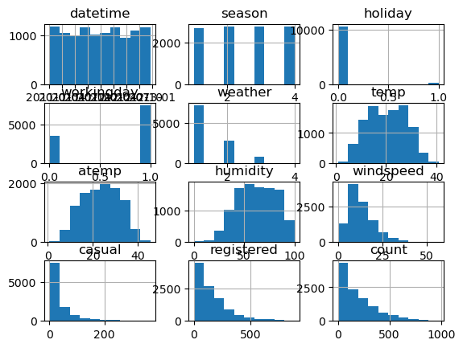

```python
# Create a histogram of all features to show the distribution of each one relative to the data. This is part of the exploritory data analysis
train.hist()
```

```python
train_set
```

[output not shown]

```python
# hour from datetime
train_set['hour'] = train['datetime'].dt.hour
test['hour'] = test['datetime'].dt.hour

# month from datetime
train_set['month'] = train['datetime'].dt.month
test['month'] = test['datetime'].dt.month

# day of the week from datetime with 0=Monday and 6=Sunday
train_set['dayofweek'] = train['datetime'].dt.dayofweek
test['dayofweek'] = test['datetime'].dt.dayofweek
```

## Make category types for these so models know they are not just numbers

- AutoGluon originally sees these as ints, but in reality they are int representations of a category.
- Setting the dtype to category will classify these as categories in AutoGluon.

```python
train_set["season"] = train_set["season"].astype("category")
train_set["weather"] = train_set["weather"].astype("category")
test["season"] = test["season"].astype("category")
test["weather"] = test["weather"].astype("category")
```

```python
# View are new feature
print(train_set.dtypes)
train_set.head()
```

```
datetime      datetime64[ns]
season              category
holiday                int64
workingday             int64
weather             category
temp                 float64
atemp                float64
humidity               int64
windspeed            float64
count                  int64
hour                   int32
month                  int32
dayofweek              int32
dtype: object
```

|  | datetime | season | holiday | workingday | weather | temp | atemp | humidity | windspeed | count | hour | month | dayofweek |
| --- | --- | --- | --- | --- | --- | --- | --- | --- | --- | --- | --- | --- | --- |
| 0 | 2011-01-01 00:00:00 | 1 | 0 | 0 | 1 | 9.84 | 14.395 | 81 | 0.0 | 16 | 0 | 1 | 5 |
| 1 | 2011-01-01 01:00:00 | 1 | 0 | 0 | 1 | 9.02 | 13.635 | 80 | 0.0 | 40 | 1 | 1 | 5 |
| 2 | 2011-01-01 02:00:00 | 1 | 0 | 0 | 1 | 9.02 | 13.635 | 80 | 0.0 | 32 | 2 | 1 | 5 |
| 3 | 2011-01-01 03:00:00 | 1 | 0 | 0 | 1 | 9.84 | 14.395 | 75 | 0.0 | 13 | 3 | 1 | 5 |
| 4 | 2011-01-01 04:00:00 | 1 | 0 | 0 | 1 | 9.84 | 14.395 | 75 | 0.0 | 1 | 4 | 1 | 5 |

[output not shown]

[figure not shown]

```python
# View histogram of all features again now with the hour feature
train.hist(figsize=(14,10))
```

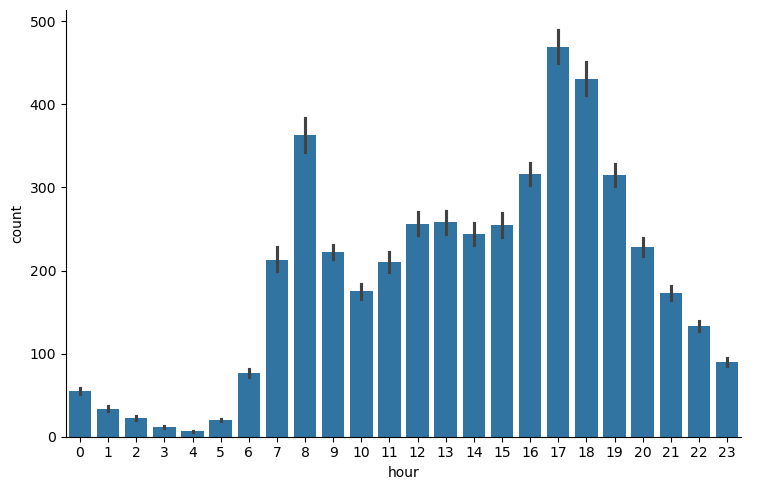

```python
import matplotlib.pyplot as plt
import seaborn as sns
# create a barplot for categorical data with seaborn
# count with respect to hour
sns.catplot(x="hour",y="count",data=train_set,kind='bar',aspect=1.5).savefig("count_hourly_barplot.png")
plt.tight_layout()
plt.show()
```

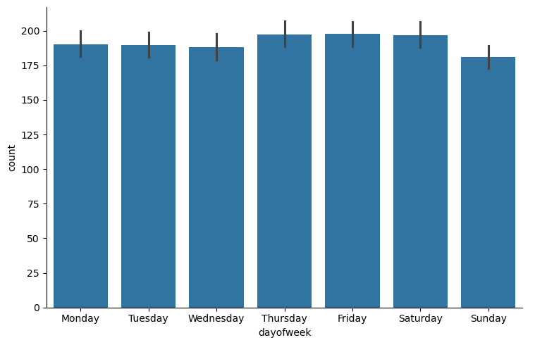

```python
# count with respect to weekday
sns.catplot(x="dayofweek",y="count",data=train_set,kind='bar',aspect=1.5).savefig("count_weekday_barplot.png")
plt.tight_layout()
plt.xticks(ticks=range(0,7), labels=["Monday", "Tuesday", "Wednesday",
                                     "Thursday", "Friday", "Saturday", "Sunday"])
plt.show()
```

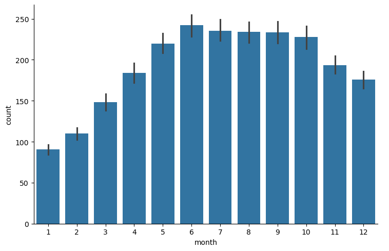

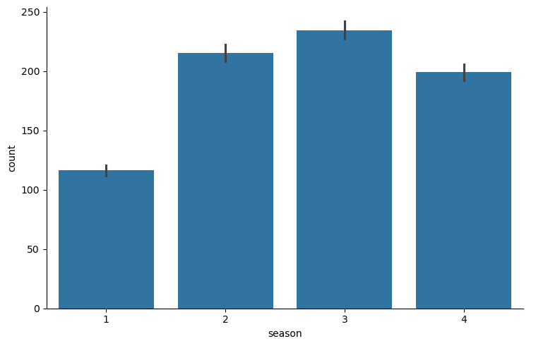

```python
# count with respect to month and season
sns.catplot(x="month",y="count",data=train_set,kind='bar',aspect=1.5).savefig("count_monthly_barplot.png")
sns.catplot(x="season",y="count",data=train_set,kind='bar',aspect=1.5).savefig("count_season_barplot.png")
plt.tight_layout()
plt.show()
```

## Step 5: Rerun the model with the same settings as before, just with more features

```python
predictor_new_features = TabularPredictor(
    label='count',
    eval_metric='root_mean_squared_error'
).fit(
    train_set,
    time_limit=600,
    presets='best_quality'
)
```

[output not shown]

[output cut: 121 more lines]

[output not shown]

```python
predictor_new_features.fit_summary()
```

```
*** Summary of fit() ***
Estimated performance of each model:
                     model   score_val              eval_metric  pred_time_val    fit_time  pred_time_val_marginal  fit_time_marginal  stack_level  can_infer  fit_order
0      WeightedEnsemble_L3  -30.355735  root_mean_squared_error      20.792665  418.740288                0.000836           0.053828            3       True         14
1          LightGBM_BAG_L2  -30.650495  root_mean_squared_error      19.205630  332.457662                0.260736          26.028440            2       True         11
2        LightGBMXT_BAG_L2  -31.095469  root_mean_squared_error      20.041267  338.563139                1.096373          32.133917            2       True         10
3          CatBoost_BAG_L2  -31.121121  root_mean_squared_error      19.068343  343.166147                0.123449          36.736925            2       True         13
4   RandomForestMSE_BAG_L2  -31.909297  root_mean_squared_error      19.311270  323.787179                0.366377          17.357957            2       True         12
5      WeightedEnsemble_L2  -32.363633  root_mean_squared_error      18.165353  265.059235                0.000887           0.045120            2       True          9
6          LightGBM_BAG_L1  -33.917164  root_mean_squared_error       3.039763   39.463201                3.039763          39.463201            1       True          4
7          CatBoost_BAG_L1  -34.503368  root_mean_squared_error       0.175114  135.714743                0.175114         135.714743            1       True          6
8        LightGBMXT_BAG_L1  -34.785281  root_mean_squared_error      14.514378   81.999700               14.514378          81.999700            1       True          3
9   RandomForestMSE_BAG_L1  -38.626522  root_mean_squared_error       0.365292    7.782178                0.365292           7.782178            1       True          5
10    ExtraTreesMSE_BAG_L1  -39.233865  root_mean_squared_error       0.302333    2.807904                0.302333           2.807904            1       True          7
11   KNeighborsDist_BAG_L1  -84.125061  root_mean_squared_error       0.069918    0.054293                0.069918           0.054293            1       True          2
12   KNeighborsUnif_BAG_L1 -101.546199  root_mean_squared_error       0.088194    0.043199                0.088194           0.043199            1       True          1
13  NeuralNetFastAI_BAG_L1 -109.322989  root_mean_squared_error       0.389901   38.564004                0.389901          38.564004            1       True          8
Number of models trained: 14
Types of models trained:
{'StackerEnsembleModel_KNN', 'StackerEnsembleModel_NNFastAiTabular', 'StackerEnsembleModel_RF', 'StackerEnsembleModel_CatBoost', 'StackerEnsembleModel_XT', 'WeightedEnsembleModel', 'StackerEnsembleModel_LGB'}
Bagging used: True  (with 8 folds)
Multi-layer stack-ensembling used: True  (with 3 levels)
Feature Metadata (Processed):
(raw dtype, special dtypes):
('category', [])             : 2 | ['season', 'weather']
('float', [])                : 3 | ['temp', 'atemp', 'windspeed']
('int', [])                  : 4 | ['humidity', 'hour', 'month', 'dayofweek']
('int', ['bool'])            : 2 | ['holiday', 'workingday']
('int', ['datetime_as_int']) : 3 | ['datetime', 'datetime.year', 'datetime.day']
*** End of fit() summary ***
```

[output not shown]

[output cut: 140 more lines]

[output not shown]

```python
# Remember to set all negative values to zero
predictions_new_features = predictor_new_features.predict(test)
predictions_new_features.head()
predictions_new_features.describe()
```

```
count    6493.000000
mean      159.773346
std       140.829544
min         2.671948
25%        49.506157
50%       123.196091
75%       229.543121
max       811.250916
Name: count, dtype: float64
```

```python
(predictions_new_features < 0).sum()
predictions_new_features[predictions_new_features < 0] = 0
```

```python
# Same submitting predictions
submission_new_features = submission
submission_new_features["count"] = predictions_new_features
submission_new_features.to_csv("submission_new_features.csv", index=False)
```

```python
submission_new_features
```

|  | datetime | count |
| --- | --- | --- |
| 0 | 2011-01-20 00:00:00 | 16.566031 |
| 1 | 2011-01-20 01:00:00 | 10.505363 |
| 2 | 2011-01-20 02:00:00 | 9.532043 |
| 3 | 2011-01-20 03:00:00 | 8.372104 |
| 4 | 2011-01-20 04:00:00 | 7.786393 |
| ... | ... | ... |
| 6488 | 2012-12-31 19:00:00 | 296.363708 |
| 6489 | 2012-12-31 20:00:00 | 207.474609 |
| 6490 | 2012-12-31 21:00:00 | 155.419800 |
| 6491 | 2012-12-31 22:00:00 | 109.136597 |
| 6492 | 2012-12-31 23:00:00 | 75.291718 |

6493 rows × 2 columns

```python
!kaggle competitions submit -c bike-sharing-demand -f submission_new_features.csv -m "new features"
```

```
Successfully submitted to Bike Sharing Demand
```

```python
!kaggle competitions submissions -c bike-sharing-demand | tail -n +1 | head -n 6
```

```
fileName                     date                        description           status                     publicScore  privateScore
---------------------------  --------------------------  --------------------  -------------------------  -----------  ------------
submission_new_features.csv  2025-05-22 10:36:06.127000  new features          SubmissionStatus.COMPLETE  0.62767      0.62767
submission.csv               2025-05-22 10:04:49.927000  first raw submission  SubmissionStatus.COMPLETE  1.80057      1.80057
```

#### New Score of `0.62767`

## Step 6: Hyper parameter optimization

- There are many options for hyper parameter optimization.
- Options are to change the AutoGluon higher level parameters or the individual model hyperparameters.
- The hyperparameters of the models themselves that are in AutoGluon. Those need the `hyperparameter` and `hyperparameter_tune_kwargs` arguments.

```python
# after taking a closer look to the fit_summary of the last predictor, GBM seemed to perform best. I will focus on tuning GBM hyperparameters
from autogluon.common import space


gbm_options = [{'extra_trees': True,
                'num_boost_round': space.Int(lower=100, upper=500, default=100),
                'num_leaves': space.Int(lower=25, upper=64, default=36),
                'ag_args': {'name_suffix': 'XT'}}, {}, 'GBMLarge']

hyperparameters = {
                   'GBM': gbm_options,
                  }


hyperparameter_tune_kwargs = {
    'num_trials': 20,
    'scheduler': 'local',
    'searcher': 'auto',
}

predictor_new_hpo = TabularPredictor(label='count',
                                     eval_metric='root_mean_squared_error'
                                     ).fit(
                                         train_data=train_set,
                                         time_limit=600,
                                         presets='best_quality',
                                         hyperparameters=hyperparameters,
                                         hyperparameter_tune_kwargs=hyperparameter_tune_kwargs,
                                         refit_full='best')
```

[output not shown]

[output cut: 47 more lines]

[output not shown]

[output not shown]

[output not shown]

[output not shown]

[output not shown]

```python
predictor_new_hpo.fit_summary()
```

```
*** Summary of fit() ***
Estimated performance of each model:
                        model  score_val              eval_metric  pred_time_val    fit_time  pred_time_val_marginal  fit_time_marginal  stack_level  can_infer  fit_order
0         WeightedEnsemble_L2 -32.787294  root_mean_squared_error       7.738034  158.729299                0.000958           0.015127            2       True          7
1         WeightedEnsemble_L3 -32.822599  root_mean_squared_error       7.869101  185.946984                0.000615           0.014933            3       True         13
2          LightGBM_BAG_L2/T1 -33.656185  root_mean_squared_error       7.868485  185.932050                0.131410          27.217879            2       True         10
3        LightGBMLarge_BAG_L1 -33.710355  root_mean_squared_error       2.411310   47.273388                2.411310          47.273388            1       True          6
4          LightGBM_BAG_L1/T2 -33.880942  root_mean_squared_error       1.719594   40.669817                1.719594          40.669817            1       True          5
5          LightGBM_BAG_L1/T1 -33.917164  root_mean_squared_error       3.126341   45.145717                3.126341          45.145717            1       True          4
6        LightGBMXT_BAG_L2/T2 -34.202112  root_mean_squared_error       7.936429  184.943085                0.199353          26.228914            2       True          9
7          LightGBM_BAG_L2/T2 -34.393544  root_mean_squared_error       7.862568  188.118731                0.125493          29.404560            2       True         11
8        LightGBMLarge_BAG_L2 -34.594543  root_mean_squared_error       8.008136  189.574088                0.271061          30.859916            2       True         12
9        LightGBMXT_BAG_L2/T1 -34.617047  root_mean_squared_error       7.886410  182.476670                0.149335          23.762498            2       True          8
10       LightGBMXT_BAG_L1/T2 -43.922261  root_mean_squared_error       0.479831   25.625248                0.479831          25.625248            1       True          2
11       LightGBMXT_BAG_L1/T3 -45.953019  root_mean_squared_error       1.022844   28.207396                1.022844          28.207396            1       True          3
12       LightGBMXT_BAG_L1/T1 -74.265159  root_mean_squared_error       0.172978   23.073596                0.172978          23.073596            1       True          1
13   WeightedEnsemble_L2_FULL        NaN  root_mean_squared_error            NaN    9.213703                     NaN           0.015127            2       True         18
14    LightGBM_BAG_L1/T2_FULL        NaN  root_mean_squared_error            NaN    2.067818                     NaN           2.067818            1       True         16
15    LightGBM_BAG_L1/T1_FULL        NaN  root_mean_squared_error            NaN    2.365974                     NaN           2.365974            1       True         15
16  LightGBMXT_BAG_L1/T2_FULL        NaN  root_mean_squared_error            NaN    1.532944                     NaN           1.532944            1       True         14
17  LightGBMLarge_BAG_L1_FULL        NaN  root_mean_squared_error            NaN    3.231840                     NaN           3.231840            1       True         17
Number of models trained: 18
Types of models trained:
{'StackerEnsembleModel_LGB', 'WeightedEnsembleModel'}
Bagging used: True  (with 8 folds)
Multi-layer stack-ensembling used: True  (with 3 levels)
Feature Metadata (Processed):
(raw dtype, special dtypes):
('category', [])             : 2 | ['season', 'weather']
('float', [])                : 3 | ['temp', 'atemp', 'windspeed']
('int', [])                  : 4 | ['humidity', 'hour', 'month', 'dayofweek']
('int', ['bool'])            : 2 | ['holiday', 'workingday']
('int', ['datetime_as_int']) : 3 | ['datetime', 'datetime.year', 'datetime.day']
*** End of fit() summary ***
```

[output not shown]

[output cut: 187 more lines]

[output not shown]

```python
# Remember to set all negative values to zero
predictions_new_hpo = predictor_new_hpo.predict(test)
predictions_new_hpo.describe()
```

```
count    6493.000000
mean      192.797241
std       173.997284
min       -12.872066
25%        46.605942
50%       152.205780
75%       285.417175
max       891.532959
Name: count, dtype: float64
```

```python
# Observation: predictions include negative values now
(predictions_new_hpo < 0).sum()
```

```
93
```

```python
predictions_new_hpo[predictions_new_hpo < 0] = 0
(predictions_new_hpo < 0).sum()
```

```
0
```

```python
# Same submitting predictions
submission_new_hpo = submission
submission_new_hpo["count"] = predictions_new_hpo
submission_new_hpo.to_csv("submission_new_hpo.csv", index=False)
```

```python
!kaggle competitions submit -c bike-sharing-demand -f submission_new_hpo.csv -m "new features with hyperparameters"
```

```
Successfully submitted to Bike Sharing Demand
```

```python
!kaggle competitions submissions -c bike-sharing-demand | tail -n +1 | head -n 6
```

```
fileName                     date                        description                        status                     publicScore  privateScore
---------------------------  --------------------------  ---------------------------------  -------------------------  -----------  ------------
submission_new_hpo.csv       2025-05-22 11:48:29.647000  new features with hyperparameters  SubmissionStatus.COMPLETE  0.52294      0.52294
submission_new_features.csv  2025-05-22 10:36:06.127000  new features                       SubmissionStatus.COMPLETE  0.62767      0.62767
submission.csv               2025-05-22 10:04:49.927000  first raw submission               SubmissionStatus.COMPLETE  1.80057      1.80057
```

#### New Score of `0.52294`

## Step 7: Write a Report

### Refer to the markdown file for the full report

### Creating plots and table for report

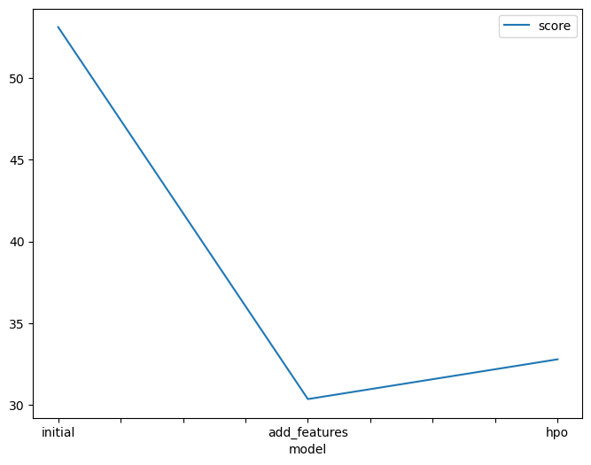

```python
# Taking the top model score from each training run and creating a line plot to show improvement
# You can create these in the notebook and save them to PNG or use some other tool (e.g. google sheets, excel)
fig = pd.DataFrame(
    {
        "model": ["initial", "add_features", "hpo"],
        "score": [53.103221, 30.355735, 32.787294]
    }
).plot(x="model", y="score", figsize=(8, 6)).get_figure()
fig.savefig('model_train_score.png')
```

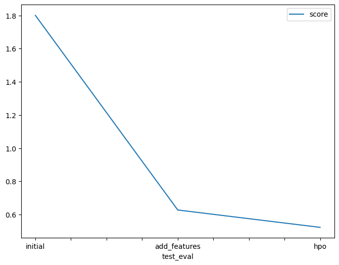

```python
# Take the 3 kaggle scores and creating a line plot to show improvement
fig = pd.DataFrame(
    {
        "test_eval": ["initial", "add_features", "hpo"],
        "score": [1.80057, 0.62767, 0.52294]
    }
).plot(x="test_eval", y="score", figsize=(8, 6)).get_figure()
fig.savefig('model_test_score.png')
```

### Hyperparameter table

```python
# The 3 hyperparameters we tuned with the kaggle score as the result
pd.DataFrame({
    "model": ["initial", "add_features", "hpo"],
    "hpo1": [None, None, "num_boost_round: 100-500"],
    "hpo2": [None, None, "num_leaves: 25-64"],
    "hpo3": [None, None, "extra_trees: True"],
    "score": [1.80057, 0.62767, 0.52294]
})
```

|  | model | hpo1 | hpo2 | hpo3 | score |
| --- | --- | --- | --- | --- | --- |
| 0 | initial | None | None | None | 1.80057 |
| 1 | add_features | None | None | None | 0.62767 |
| 2 | hpo | num_boost_round: 100-500 | num_leaves: 25-64 | extra_trees: True | 0.52294 |

```python
predictor_new_hpo.leaderboard(silent=True)
```

|  | model | score_val | eval_metric | pred_time_val | fit_time | pred_time_val_marginal | fit_time_marginal | stack_level | can_infer | fit_order |
| --- | --- | --- | --- | --- | --- | --- | --- | --- | --- | --- |
| 0 | WeightedEnsemble_L2 | -32.787294 | root_mean_squared_error | 7.738034 | 158.729299 | 0.000958 | 0.015127 | 2 | True | 7 |
| 1 | WeightedEnsemble_L3 | -32.822599 | root_mean_squared_error | 7.869101 | 185.946984 | 0.000615 | 0.014933 | 3 | True | 13 |
| 2 | LightGBM_BAG_L2/T1 | -33.656185 | root_mean_squared_error | 7.868485 | 185.932050 | 0.131410 | 27.217879 | 2 | True | 10 |
| 3 | LightGBMLarge_BAG_L1 | -33.710355 | root_mean_squared_error | 2.411310 | 47.273388 | 2.411310 | 47.273388 | 1 | True | 6 |
| 4 | LightGBM_BAG_L1/T2 | -33.880942 | root_mean_squared_error | 1.719594 | 40.669817 | 1.719594 | 40.669817 | 1 | True | 5 |
| 5 | LightGBM_BAG_L1/T1 | -33.917164 | root_mean_squared_error | 3.126341 | 45.145717 | 3.126341 | 45.145717 | 1 | True | 4 |
| 6 | LightGBMXT_BAG_L2/T2 | -34.202112 | root_mean_squared_error | 7.936429 | 184.943085 | 0.199353 | 26.228914 | 2 | True | 9 |
| 7 | LightGBM_BAG_L2/T2 | -34.393544 | root_mean_squared_error | 7.862568 | 188.118731 | 0.125493 | 29.404560 | 2 | True | 11 |
| 8 | LightGBMLarge_BAG_L2 | -34.594543 | root_mean_squared_error | 8.008136 | 189.574088 | 0.271061 | 30.859916 | 2 | True | 12 |
| 9 | LightGBMXT_BAG_L2/T1 | -34.617047 | root_mean_squared_error | 7.886410 | 182.476670 | 0.149335 | 23.762498 | 2 | True | 8 |
| 10 | LightGBMXT_BAG_L1/T2 | -43.922261 | root_mean_squared_error | 0.479831 | 25.625248 | 0.479831 | 25.625248 | 1 | True | 2 |
| 11 | LightGBMXT_BAG_L1/T3 | -45.953019 | root_mean_squared_error | 1.022844 | 28.207396 | 1.022844 | 28.207396 | 1 | True | 3 |
| 12 | LightGBMXT_BAG_L1/T1 | -74.265159 | root_mean_squared_error | 0.172978 | 23.073596 | 0.172978 | 23.073596 | 1 | True | 1 |
| 13 | WeightedEnsemble_L2_FULL | NaN | root_mean_squared_error | NaN | 9.213703 | NaN | 0.015127 | 2 | True | 18 |
| 14 | LightGBM_BAG_L1/T2_FULL | NaN | root_mean_squared_error | NaN | 2.067818 | NaN | 2.067818 | 1 | True | 16 |
| 15 | LightGBM_BAG_L1/T1_FULL | NaN | root_mean_squared_error | NaN | 2.365974 | NaN | 2.365974 | 1 | True | 15 |
| 16 | LightGBMXT_BAG_L1/T2_FULL | NaN | root_mean_squared_error | NaN | 1.532944 | NaN | 1.532944 | 1 | True | 14 |
| 17 | LightGBMLarge_BAG_L1_FULL | NaN | root_mean_squared_error | NaN | 3.231840 | NaN | 3.231840 | 1 | True | 17 |